GeoStat Lab · M11 · Statistica spaziale

M11_N18 · Locus

# IDW: interpolare con pesi espliciti

5 blocchi R eseguiti1 grafico0 errori · 0 avvisiOffline · MathML

Codice, output e figure dello stesso svolgimento. Ogni notebook riparte dai dati locali ed è autonomo rispetto agli altri.

# La domanda

Come si costruisce una previsione IDW e quali limiti impongono i suoi pesi?

## Obiettivi

- Calcolare le tre potenze originali nel punto (900,900).
- Verificare normalizzazione e limite all’intervallo osservato.
- Dichiarare il comportamento con siti coincidenti.

**Prima di iniziare.** Sono richiesti vettori, tabelle, coordinate e funzioni R di base. I blocchi vanno eseguiti in ordine; il notebook è autonomo rispetto agli altri. I calcoli usano R base e i pacchetti standard.

**Dati e unità.** 64 siti sintetici su una griglia 8 × 8, con passo 250 m e coordinate locali x_m e y_m fra 0 e 1750 m. Questo piano locale non ha un codice EPSG. La concentrazione è sintetica, in unità arbitrarie (u.a.); la quota è in metri sintetici. Ogni riga descrive un sito e il suo valore puntuale, non la media di una cella.

## Preparazione

Aprire il progetto autonomo di Locus o quello generale dei notebook. I CSV locali restano invariati. Gli output vanno in `Risultati/M11_N18/`. Nessun download o installazione viene eseguito nei blocchi.

Codice R · preparazione

```r
# Trova il modulo dal progetto autonomo o dal progetto generale dei notebook.
.gs_cerca <- normalizePath(getwd(),winslash="/",mustWork=TRUE)
repeat {
  .gs_candidati <- c(.gs_cerca,file.path(.gs_cerca,"M11_Locus"),
    file.path(.gs_cerca,"03_Notebook_svolti","M11_Locus"),
    file.path(.gs_cerca,"M11","03_Notebook_svolti","M11_Locus"))
  .gs_ok <- file.exists(file.path(.gs_candidati,"M11_N01.Rmd")) &
    file.exists(file.path(.gs_candidati,"R","funzioni_notebook.R"))
  if(any(.gs_ok)) { .gs_modulo <- .gs_candidati[which(.gs_ok)[1L]];break }
  .gs_padre <- dirname(.gs_cerca)
  if(.gs_padre==.gs_cerca) stop("Aprire il progetto M11_Locus o quello generale dei notebook.")
  .gs_cerca <- .gs_padre
}
source(file.path(.gs_modulo,"R","funzioni_notebook.R"),local=TRUE)
.gs_funzioni <- .gs_prepara_notebook(.gs_modulo,"M11_N18")
carica_dati <- .gs_funzioni$carica_dati
percorso_risultati <- .gs_funzioni$percorso_risultati
options(width=88,digits=6)
if(requireNamespace("knitr",quietly=TRUE)) {
  knitr::opts_chunk$set(echo=TRUE,error=FALSE,warning=TRUE,message=TRUE,
    fig.width=8,fig.height=5,dpi=150,fig.align="center")
}
set.seed(11018)
```

## 1. Il punto richiesto non coincide con un sito

Manteniamo la posizione (900,900)m e le potenze 1,2,3 dello script originale. Non c’è un valore osservato in quella posizione da usare per scegliere la potenza.

Codice R · passo_01

```r
d <- carica_dati("spazio_v3.csv")
audit_spazio(d)
 posizione <- c(900,900);xy <- as.matrix(d[c("x_m","y_m")])
 r <- sqrt((d$x_m-posizione[1])^2+(d$y_m-posizione[2])^2)
 stopifnot(all(r>0))
 data.frame(x_m=posizione[1],y_m=posizione[2],distanza_minima_m=min(r),distanza_massima_m=max(r))
```

Output eseguito

```
  x_m y_m distanza_minima_m distanza_massima_m
1 900 900           141.421            1272.79
```

**Lettura del risultato.** La richiesta è una previsione puntuale nel piano locale. La posizione e l’esponente vanno dichiarati prima di interpretare il numero restituito.

## 2. I pesi sono positivi e sommano a uno

Per distanze positive, $w_i=r_i^{-p}/\sum_jr_j^{-p}$ e $\hat z=\sum_iw_i z_i$. L’esponente maggiore concentra più peso sui siti vicini.

Codice R · passo_02

```r
potenze <- 1:3
pesi <- sapply(potenze,function(p) {w<-r^-p;w/sum(w)})
q <- as.numeric(crossprod(d$concentrazione,pesi))
risultato <- data.frame(potenza=potenze,previsione=q,somma_pesi=colSums(pesi),
  peso_massimo=apply(pesi,2,max))
risultato
stopifnot(max(abs(colSums(pesi)-1))<1e-12,all(pesi>=0),
  all(q>=min(d$concentrazione)&q<=max(d$concentrazione)))
```

Output eseguito

```
  potenza previsione somma_pesi peso_massimo
1       1    17.3722          1    0.0661367
2       2    17.6256          1    0.1863791
3       3    17.8697          1    0.3380639
```

**Lettura del risultato.** La previsione è una combinazione convessa dei valori usati. Non può oltrepassarne l’intervallo e non possiede automaticamente un intervallo d’incertezza statistica.

## 3. Il registro rende esplicita l’influenza dei siti

Confrontiamo i pesi in funzione della distanza e salviamo ogni contributo.

Codice R · passo_03

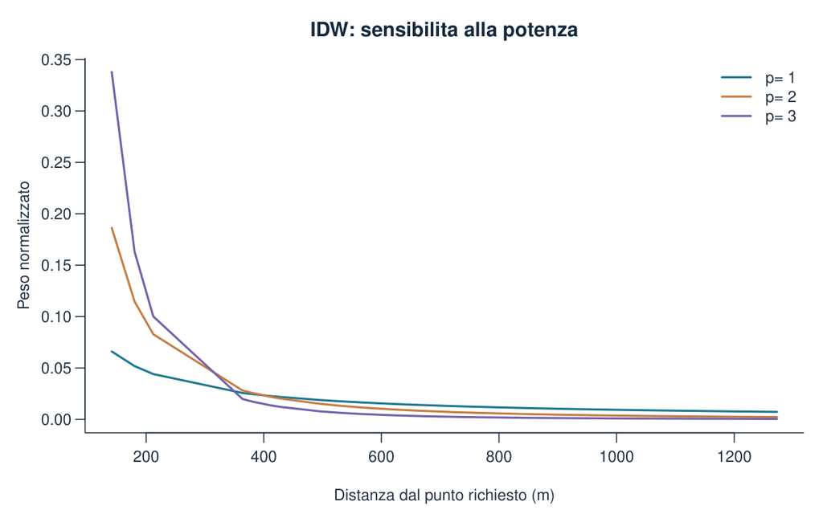

Figura 1 · Output del blocco `passo_03`. PDF vettoriale.

```r
ordine <- order(r)
stile_grafico()
matplot(r[ordine],pesi[ordine,],type="l",lty=1,col=palette_geo[1:3],lwd=2,
  xlab="Distanza dal punto richiesto (m)",ylab="Peso normalizzato",main="IDW: sensibilita alla potenza")
legend("topright",paste("p=",potenze),col=palette_geo[1:3],lty=1,lwd=2,bty="n")
write.csv(risultato,percorso_risultati("IDW_potenze.csv"),row.names=FALSE)
write.csv(data.frame(id=d$id,distanza_m=r,p1=pesi[,1],p2=pesi[,2],p3=pesi[,3]),
  percorso_risultati("IDW_pesi.csv"),row.names=FALSE)
stopifnot(abs(idw_pred(xy,d$concentrazione,matrix(posizione,nrow=1),2)-q[2])<1e-12)
```

**Lettura del risultato.** Una sensibilità alla potenza non dice quale previsione sia più accurata. La verifica richiede bersagli esclusi e un protocollo separato, come in N19.

## Variante svolta

**Coincidenza e duplicati hanno una regola esplicita.** La funzione assegna tutto il peso ai siti coincidenti entro 10⁻¹⁰ m e, se sono più di uno, usa la loro media.

Codice R · variante

```r
esatto <- idw_pred(xy,d$concentrazione,xy[1,,drop=FALSE],2)
duplicati <- matrix(c(0,0,0,0,100,0),ncol=2,byrow=TRUE)
esempio <- idw_pred(duplicati,c(10,14,100),matrix(c(0,0),nrow=1),2)
data.frame(caso=c("S01 osservato","Due valori coincidenti 10 e 14"),previsione=c(esatto,esempio))
stopifnot(abs(esatto-d$concentrazione[1])<1e-12,esempio==12)
```

Output eseguito

```
                            caso previsione
1                  S01 osservato    12.6653
2 Due valori coincidenti 10 e 14    12.0000
```

La media dei coincidenti è una politica computazionale dichiarata. Prima di applicarla a dati reali si deve capire se si tratta di repliche, duplicati o errori di posizione.

## Errore da riconoscere

Calcolare 0 elevato a una potenza negativa, scegliere p usando un bersaglio non osservato o interpretare la superficie IDW come una misura.

## Risposta alla domanda

IDW media valori con pesi espliciti legati alla distanza. La potenza controlla la località e la previsione resta nell’intervallo dei dati usati. Coincidenze, unità e scelta dei parametri vanno dichiarate; la precisione richiede una verifica indipendente.

## Raccordo con le slide

Slide 92–95 della lezione Locus. Il notebook conserva il tema del laboratorio originale e aggiunge verifiche e una variante svolta.

## Riferimenti e provenienza

Questo svolgimento sviluppa `M11_N18` del [modulo M11 del corso](https://marzione00.github.io/Lab_Geo/#modulo-M11). Il [codice originale](https://github.com/marzione00/Lab_Geo/blob/649f7cc577b96bd1044d81e78a2f530813e4f96b/materiali/laboratori/M11/M11_N18.R) è conservato immutato in `R/Originali_corso/`; la mappa allegata documenta gli ampliamenti. Dati e originali hanno impronte SHA-256 e SHA-1 Git verificate.

Documentazione primaria delle operazioni: [R, dist](https://stat.ethz.ch/R-manual/R-devel/library/stats/html/dist.html), [R, aggregate](https://stat.ethz.ch/R-manual/R-devel/library/stats/html/aggregate.html), [R, sample](https://stat.ethz.ch/R-manual/R-devel/library/base/html/sample.html). Le definizioni spaziali e il riferimento inferenziale seguono il laboratorio originale, con le distinzioni esplicitate nel testo.